# R Notebook

```r
library(tidyverse)
library(leaps)
library(janitor)
library(e1071)
library(ggfortify)
library(GGally)

avocado <- read_csv("data/avocado.csv") %>%
  clean_names()

  # mutate(type = factor(type, c(0, 1), labels = c("conventional", "organic")))

# convert catagoricals to factors
avocado$type <- factor(avocado$type)

avocado$year <- factor(avocado$year)

avocado$region <- factor(avocado$region)
```

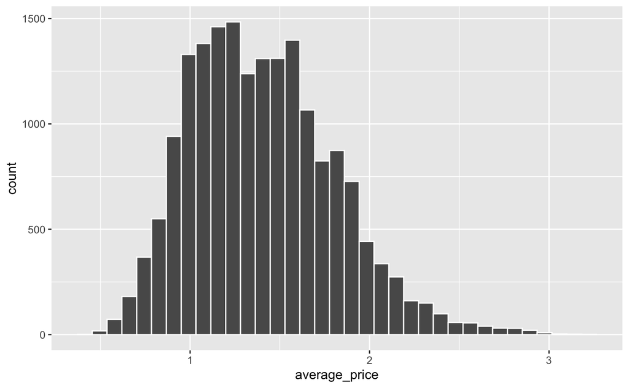

```r
# let's look at the distribution of average_price
avocado %>%
  ggplot() +
  aes(x = average_price) %>%
  geom_histogram(bins = 35, colour = "white")
```

```r
skewness(avocado$average_price)
```

```
[1] 0.5802073
```

```r
# distribution of price has good normality with a moderate right skew
```

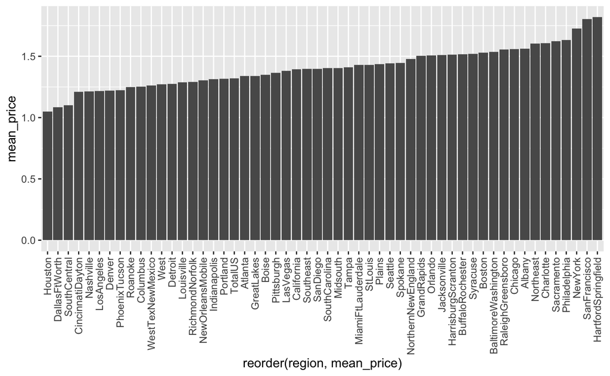

```r
# how does average_price vary with region
avocado %>%
  group_by(region) %>%
  summarise(mean_price = mean(average_price)) %>%
  ggplot() +
  aes(x = reorder(region, mean_price), y = mean_price) +
  geom_col() +
  theme(axis.text.x = element_text(angle = 90, vjust = 0.5, hjust=1))
```

```r
# create test and train datasets
n_data <- nrow(avocado) # count number of rows in our dataset

 # create a test index
test_index <- sample(1:n_data, size = n_data * 0.2)

# use test_index to create test and train datasets
test <- slice(avocado, test_index)
train <- slice(avocado, -test_index)
```

[output not shown]

[output cut: 84 more lines]

[output not shown]

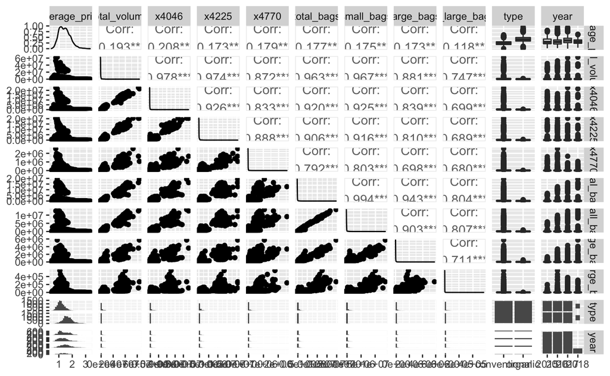

```r
avocado_trimmed <- avocado %>%
  select(-c(region, date, x1))

ggpairs(avocado_trimmed)
```

# manual model building

According to the ggpairs plot x4046 is most correlated with average_price, then total_volume, x4770, etc. Type is also looking interesting so I will begin with type then the different avocado type and so on.

```r
model_1 <- lm(average_price ~ type, data = avocado_trimmed)
summary(model_1)
```

```
Call:
lm(formula = average_price ~ type, data = avocado_trimmed)

Residuals:
     Min       1Q   Median       3Q      Max
-1.21400 -0.20400 -0.02804  0.18600  1.59600

Coefficients:
            Estimate Std. Error t value Pr(>|t|)
(Intercept) 1.158040   0.003321   348.7   <2e-16 ***
typeorganic 0.495959   0.004697   105.6   <2e-16 ***
---
Signif. codes:  0 ‘***’ 0.001 ‘**’ 0.01 ‘*’ 0.05 ‘.’ 0.1 ‘ ’ 1

Residual standard error: 0.3173 on 18247 degrees of freedom
Multiple R-squared:  0.3793,    Adjusted R-squared:  0.3792
F-statistic: 1.115e+04 on 1 and 18247 DF,  p-value: < 2.2e-16
```

```r
model_2 <- lm(average_price ~ x4046, data = avocado_trimmed)
summary(model_2)
```

```
Call:
lm(formula = average_price ~ x4046, data = avocado_trimmed)

Residuals:
     Min       1Q   Median       3Q      Max
-0.98539 -0.29842 -0.03531  0.25459  1.82475

Coefficients:
              Estimate Std. Error t value Pr(>|t|)
(Intercept)  1.425e+00  2.993e-03  476.29   <2e-16 ***
x4046       -6.631e-08  2.305e-09  -28.77   <2e-16 ***
---
Signif. codes:  0 ‘***’ 0.001 ‘**’ 0.01 ‘*’ 0.05 ‘.’ 0.1 ‘ ’ 1

Residual standard error: 0.3939 on 18247 degrees of freedom
Multiple R-squared:  0.0434,    Adjusted R-squared:  0.04334
F-statistic: 827.8 on 1 and 18247 DF,  p-value: < 2.2e-16
```

```r
model_3 <- lm(average_price ~ total_volume, data = avocado_trimmed)
summary(model_3)
```

```
Call:
lm(formula = average_price ~ total_volume, data = avocado_trimmed)

Residuals:
     Min       1Q   Median       3Q      Max
-0.98366 -0.29994 -0.03319  0.25498  1.82528

Coefficients:
               Estimate Std. Error t value Pr(>|t|)
(Intercept)   1.425e+00  3.012e-03  473.07   <2e-16 ***
total_volume -2.247e-08  8.470e-10  -26.54   <2e-16 ***
---
Signif. codes:  0 ‘***’ 0.001 ‘**’ 0.01 ‘*’ 0.05 ‘.’ 0.1 ‘ ’ 1

Residual standard error: 0.3951 on 18247 degrees of freedom
Multiple R-squared:  0.03715,   Adjusted R-squared:  0.0371
F-statistic: 704.1 on 1 and 18247 DF,  p-value: < 2.2e-16
```

```r
model_4 <- lm(average_price ~ x4225, data = avocado_trimmed)
summary(model_4)
```

```
Call:
lm(formula = average_price ~ x4225, data = avocado_trimmed)

Residuals:
     Min       1Q   Median       3Q      Max
-0.98277 -0.29964 -0.02891  0.25697  1.82760

Coefficients:
              Estimate Std. Error t value Pr(>|t|)
(Intercept)  1.423e+00  3.023e-03  470.75   <2e-16 ***
x4225       -5.783e-08  2.438e-09  -23.72   <2e-16 ***
---
Signif. codes:  0 ‘***’ 0.001 ‘**’ 0.01 ‘*’ 0.05 ‘.’ 0.1 ‘ ’ 1

Residual standard error: 0.3966 on 18247 degrees of freedom
Multiple R-squared:  0.0299,    Adjusted R-squared:  0.02985
F-statistic: 562.5 on 1 and 18247 DF,  p-value: < 2.2e-16
```

```r
model_6 <- lm(average_price ~ x4770, data = avocado_trimmed)
summary(model_6)
```

```
Call:
lm(formula = average_price ~ x4770, data = avocado_trimmed)

Residuals:
     Min       1Q   Median       3Q      Max
-0.98134 -0.29852 -0.03134  0.24887  1.82866

Coefficients:
              Estimate Std. Error t value Pr(>|t|)
(Intercept)  1.421e+00  2.998e-03  474.09   <2e-16 ***
x4770       -6.724e-07  2.729e-08  -24.64   <2e-16 ***
---
Signif. codes:  0 ‘***’ 0.001 ‘**’ 0.01 ‘*’ 0.05 ‘.’ 0.1 ‘ ’ 1

Residual standard error: 0.3962 on 18247 degrees of freedom
Multiple R-squared:  0.0322,    Adjusted R-squared:  0.03215
F-statistic: 607.1 on 1 and 18247 DF,  p-value: < 2.2e-16
```

```r
model_7 <- lm(average_price ~ total_bags, data = avocado_trimmed)
summary(model_7)
```

```
Call:
lm(formula = average_price ~ total_bags, data = avocado_trimmed)

Residuals:
     Min       1Q   Median       3Q      Max
-0.97903 -0.30046 -0.03232  0.25174  1.82693

Coefficients:
              Estimate Std. Error t value Pr(>|t|)
(Intercept)  1.423e+00  3.019e-03   471.4   <2e-16 ***
total_bags  -7.230e-08  2.975e-09   -24.3   <2e-16 ***
---
Signif. codes:  0 ‘***’ 0.001 ‘**’ 0.01 ‘*’ 0.05 ‘.’ 0.1 ‘ ’ 1

Residual standard error: 0.3963 on 18247 degrees of freedom
Multiple R-squared:  0.03136,   Adjusted R-squared:  0.03131
F-statistic: 590.8 on 1 and 18247 DF,  p-value: < 2.2e-16
```

```r
model_8 <- lm(average_price ~ year, data = avocado_trimmed)
summary(model_8)
```

```
Call:
lm(formula = average_price ~ year, data = avocado_trimmed)

Residuals:
     Min       1Q   Median       3Q      Max
-1.07513 -0.29513 -0.03559  0.25247  1.91136

Coefficients:
             Estimate Std. Error t value Pr(>|t|)
(Intercept)  1.375590   0.005280 260.546  < 2e-16 ***
year2016    -0.036951   0.007466  -4.949 7.52e-07 ***
year2017     0.139537   0.007432  18.776  < 2e-16 ***
year2018    -0.028060   0.012192  -2.301   0.0214 *
---
Signif. codes:  0 ‘***’ 0.001 ‘**’ 0.01 ‘*’ 0.05 ‘.’ 0.1 ‘ ’ 1

Residual standard error: 0.3956 on 18245 degrees of freedom
Multiple R-squared:  0.03489,   Adjusted R-squared:  0.03474
F-statistic: 219.9 on 3 and 18245 DF,  p-value: < 2.2e-16
```

So it is type which provides the highest r2 value ~38%, which is to say that 38% of the variation in average price of avocados can be explained by variation in type, i.e. whether an avocado is organic or not - this makes sense!

The remaining predictors do not account for much variation in average_price

# auto model development

```r
auto_exhaustive_1 <- regsubsets(average_price ~ ., data = avocado_trimmed, method = "exhaustive")
sum_auto_exhaustive <- summary(auto_exhaustive_1)
sum_auto_exhaustive
```

```
Subset selection object
Call: regsubsets.formula(average_price ~ ., data = avocado_trimmed,
    method = "exhaustive")
12 Variables  (and intercept)
             Forced in Forced out
total_volume     FALSE      FALSE
x4046            FALSE      FALSE
x4225            FALSE      FALSE
x4770            FALSE      FALSE
total_bags       FALSE      FALSE
small_bags       FALSE      FALSE
large_bags       FALSE      FALSE
x_large_bags     FALSE      FALSE
typeorganic      FALSE      FALSE
year2016         FALSE      FALSE
year2017         FALSE      FALSE
year2018         FALSE      FALSE
1 subsets of each size up to 8
Selection Algorithm: exhaustive
         total_volume x4046 x4225 x4770 total_bags small_bags large_bags x_large_bags typeorganic year2016 year2017
1  ( 1 ) " "          " "   " "   " "   " "        " "        " "        " "          "*"         " "      " "
2  ( 1 ) " "          " "   " "   " "   " "        " "        " "        " "          "*"         " "      "*"
3  ( 1 ) " "          "*"   " "   " "   " "        " "        " "        " "          "*"         " "      "*"
4  ( 1 ) " "          "*"   "*"   " "   " "        " "        " "        " "          "*"         " "      "*"
5  ( 1 ) "*"          " "   "*"   " "   " "        "*"        " "        " "          "*"         " "      "*"
6  ( 1 ) "*"          " "   "*"   " "   " "        "*"        " "        " "          "*"         "*"      "*"
7  ( 1 ) "*"          " "   "*"   " "   " "        "*"        " "        "*"          "*"         "*"      "*"
8  ( 1 ) " "          "*"   "*"   "*"   " "        " "        "*"        "*"          "*"         "*"      "*"
         year2018
1  ( 1 ) " "
2  ( 1 ) " "
3  ( 1 ) " "
4  ( 1 ) " "
5  ( 1 ) " "
6  ( 1 ) " "
7  ( 1 ) " "
8  ( 1 ) " "
```

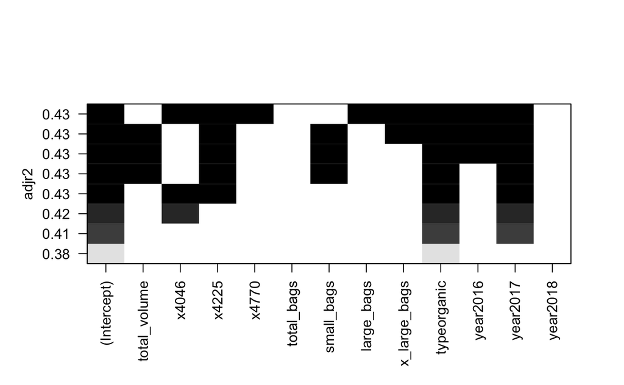

```r
plot(auto_exhaustive_1, scale = "adjr2")
```

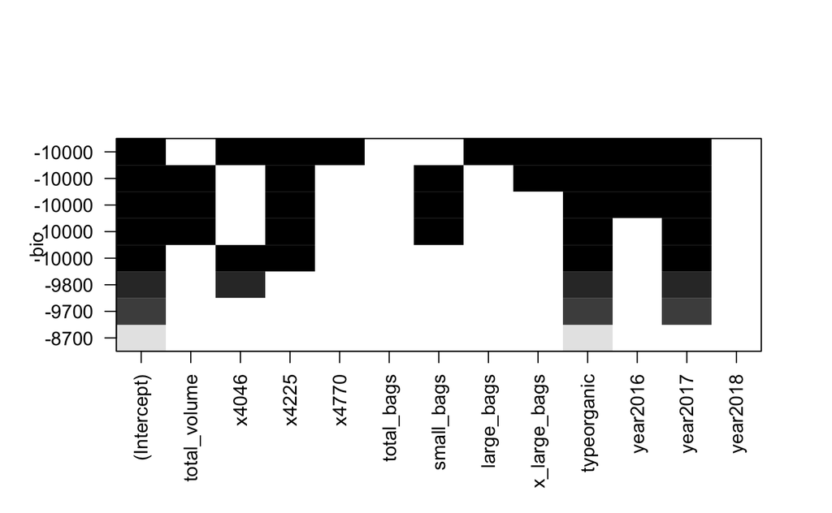

```r
plot(auto_exhaustive_1, scale = "bic")
```

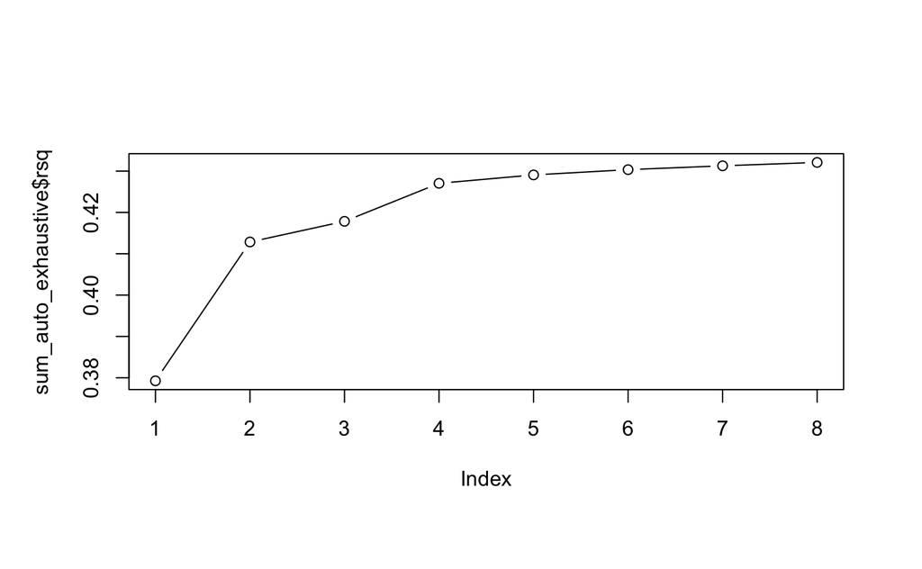

```r
plot(sum_auto_exhaustive$rsq, type = "b")
```

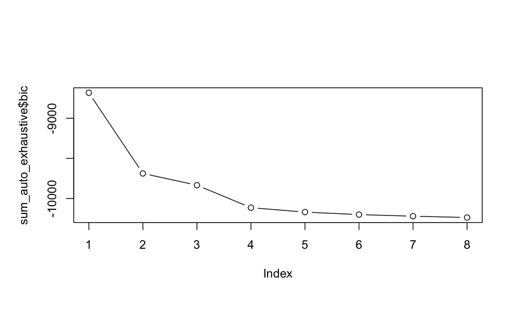

```r
plot(sum_auto_exhaustive$bic, type = "b")
```

The model with highest adjusted r2 value is one containing x4046 + x4225 + x4770 + large_bags + x_large_bags + type + year but we are not testing for statistical significance. To do this a model will be build using these variables plus a model which contains region from the original avocado dataset, then perform an analysis of variance test to see which model is best.

```r
model_1a <- lm(average_price ~ x4046 + x4225 + x4770 + large_bags + x_large_bags + type + year, data = avocado_trimmed)
summary(model_1a)
```

```
Call:
lm(formula = average_price ~ x4046 + x4225 + x4770 + large_bags +
    x_large_bags + type + year, data = avocado_trimmed)

Residuals:
     Min       1Q   Median       3Q      Max
-1.31636 -0.18309 -0.01701  0.17658  1.66268

Coefficients:
               Estimate Std. Error t value Pr(>|t|)
(Intercept)   1.135e+00  4.801e-03 236.456  < 2e-16 ***
x4046        -9.121e-08  5.192e-09 -17.567  < 2e-16 ***
x4225         1.110e-07  6.089e-09  18.226  < 2e-16 ***
x4770        -3.717e-07  4.744e-08  -7.835 4.93e-15 ***
large_bags   -1.223e-07  1.845e-08  -6.630 3.46e-11 ***
x_large_bags  1.717e-06  1.951e-07   8.802  < 2e-16 ***
typeorganic   4.883e-01  4.622e-03 105.648  < 2e-16 ***
year2016     -3.712e-02  5.785e-03  -6.416 1.43e-10 ***
year2017      1.396e-01  5.791e-03  24.105  < 2e-16 ***
year2018     -2.555e-02  9.444e-03  -2.705  0.00683 **
---
Signif. codes:  0 ‘***’ 0.001 ‘**’ 0.01 ‘*’ 0.05 ‘.’ 0.1 ‘ ’ 1

Residual standard error: 0.3035 on 18239 degrees of freedom
Multiple R-squared:  0.4323,    Adjusted R-squared:  0.432
F-statistic:  1543 on 9 and 18239 DF,  p-value: < 2.2e-16
```

```r
model_2a <- lm(average_price ~ x4046 + x4225 + x4770 + large_bags + x_large_bags + type + year + region, data = avocado)
summary(model_2a)
```

```
Call:
lm(formula = average_price ~ x4046 + x4225 + x4770 + large_bags +
    x_large_bags + type + year + region, data = avocado)

Residuals:
     Min       1Q   Median       3Q      Max
-1.14148 -0.14869 -0.00614  0.14129  1.48528

Coefficients:
                            Estimate Std. Error t value Pr(>|t|)
(Intercept)                1.287e+00  1.460e-02  88.153  < 2e-16 ***
x4046                     -2.864e-09  5.403e-09  -0.530 0.596005
x4225                     -1.306e-08  6.527e-09  -2.000 0.045497 *
x4770                      1.367e-08  4.410e-08   0.310 0.756579
large_bags                -5.317e-08  1.753e-08  -3.033 0.002427 **
x_large_bags               1.365e-06  1.735e-07   7.866 3.87e-15 ***
typeorganic                4.911e-01  4.071e-03 120.637  < 2e-16 ***
year2016                  -3.892e-02  4.965e-03  -7.839 4.80e-15 ***
year2017                   1.371e-01  4.969e-03  27.595  < 2e-16 ***
year2018                  -3.027e-02  8.103e-03  -3.735 0.000188 ***
regionAtlanta             -2.221e-01  2.003e-02 -11.088  < 2e-16 ***
regionBaltimoreWashington -2.472e-02  2.004e-02  -1.234 0.217222
regionBoise               -2.132e-01  2.001e-02 -10.651  < 2e-16 ***
regionBoston              -2.789e-02  2.004e-02  -1.392 0.163917
regionBuffaloRochester    -4.430e-02  2.001e-02  -2.214 0.026856 *
regionCalifornia          -1.698e-01  2.036e-02  -8.339  < 2e-16 ***
regionCharlotte            4.488e-02  2.002e-02   2.242 0.024970 *
regionChicago             -3.297e-03  2.012e-02  -0.164 0.869806
regionCincinnatiDayton    -3.502e-01  2.002e-02 -17.488  < 2e-16 ***
regionColumbus            -3.090e-01  2.001e-02 -15.439  < 2e-16 ***
regionDallasFtWorth       -4.742e-01  2.005e-02 -23.650  < 2e-16 ***
regionDenver              -3.347e-01  2.010e-02 -16.649  < 2e-16 ***
regionDetroit             -2.913e-01  2.005e-02 -14.530  < 2e-16 ***
regionGrandRapids         -5.914e-02  2.002e-02  -2.955 0.003133 **
regionGreatLakes          -2.319e-01  2.065e-02 -11.229  < 2e-16 ***
regionHarrisburgScranton  -4.780e-02  2.001e-02  -2.389 0.016910 *
regionHartfordSpringfield  2.585e-01  2.002e-02  12.913  < 2e-16 ***
regionHouston             -5.096e-01  2.004e-02 -25.425  < 2e-16 ***
regionIndianapolis        -2.472e-01  2.001e-02 -12.355  < 2e-16 ***
regionJacksonville        -4.980e-02  2.001e-02  -2.488 0.012846 *
```

[output cut: 24 more lines]

```
regionSouthCentral        -4.515e-01  2.072e-02 -21.788  < 2e-16 ***
regionSoutheast           -1.560e-01  2.046e-02  -7.624 2.58e-14 ***
regionSpokane             -1.155e-01  2.001e-02  -5.772 7.96e-09 ***
regionStLouis             -1.310e-01  2.001e-02  -6.548 6.00e-11 ***
regionSyracuse            -4.093e-02  2.001e-02  -2.046 0.040818 *
regionTampa               -1.514e-01  2.002e-02  -7.565 4.06e-14 ***
regionTotalUS             -1.813e-01  2.455e-02  -7.387 1.57e-13 ***
regionWest                -2.558e-01  2.082e-02 -12.286  < 2e-16 ***
regionWestTexNewMexico    -2.944e-01  2.009e-02 -14.652  < 2e-16 ***
---
Signif. codes:  0 ‘***’ 0.001 ‘**’ 0.01 ‘*’ 0.05 ‘.’ 0.1 ‘ ’ 1

Residual standard error: 0.2601 on 18186 degrees of freedom
Multiple R-squared:  0.5841,    Adjusted R-squared:  0.5827
F-statistic:   412 on 62 and 18186 DF,  p-value: < 2.2e-16
```

```r
anova(model_1a, model_2a)
```

```
Analysis of Variance Table

Model 1: average_price ~ x4046 + x4225 + x4770 + large_bags + x_large_bags +
    type + year
Model 2: average_price ~ x4046 + x4225 + x4770 + large_bags + x_large_bags +
    type + year + region
  Res.Df    RSS Df Sum of Sq      F    Pr(>F)
1  18239 1679.7
2  18186 1230.6 53    449.12 125.23 < 2.2e-16 ***
---
Signif. codes:  0 ‘***’ 0.001 ‘**’ 0.01 ‘*’ 0.05 ‘.’ 0.1 ‘ ’ 1
```

The model without region has an r2 value of 0.43 but the model including region has r2 value of 0.58, and the anova test tells us that the model with region is significantly better at predicting variance in average_price than the model without.

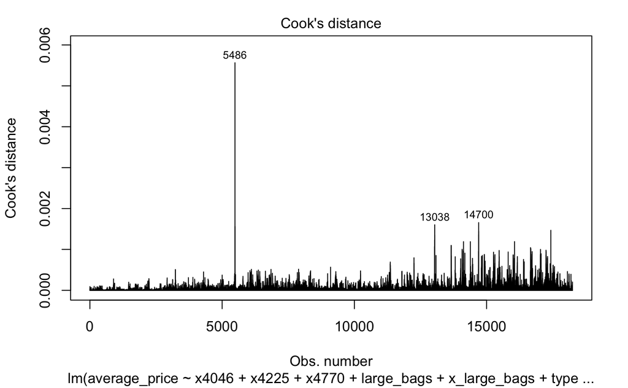